# Introduction

This notebook illustrates design and optimization of a custom passive component within the IPKISS framework.

1. Creation of a PCell for a splitter. The splitter should be parametrized in such a way that it can be optimized for performance by varying those parameters.
2. Optimization of the splitter: Using intuition, a fast and approximate simulation and optimization method for obtaining a good splitter is proposed. In this notebook we will use **CAMFR** as a solver.
3. The proposed splitter is verified using an accurate 3D-FIT/FDTD simulation. An accurate s-matrix model is created for the splitter. In this notebook we will use **CST Microwave Studio** as an engine for this FIT/FDTD simulation and the s-matrix extraction.

First, import the technology, ipkiss and utility libraries

```python
import sys
from technologies import silicon_photonics
from ipkiss3 import all as i3
```

```python
sys.path.append('.')
%pylab inline
pylab.rcParams['figure.figsize'] = (12, 6)
# A Few more imports
import numpy as np
import shutil
```

## Step 1: Creation of the Splitter PCell

We create a class SplitterWaypoint:

Splitters: splitters.py

<img src="_images/optimized_splitter.png" width=650>

As indicated in the image above, the splitter's layout has a number of properties that describe its shape.

The outer boundary of the splitting shape is formed by a smooth spline that has the following properties:

- The spline has a zero derivative at the start and at the end.
- The spline passes through a waypoint with coordinates set by the waypoint property.

The inner boundary of the splitter is approximated by a parabole that is qualitatively described by

- split_base_width
- split_base_pos

as indicated in the illustration. Use the cell below to play with the properties a little.

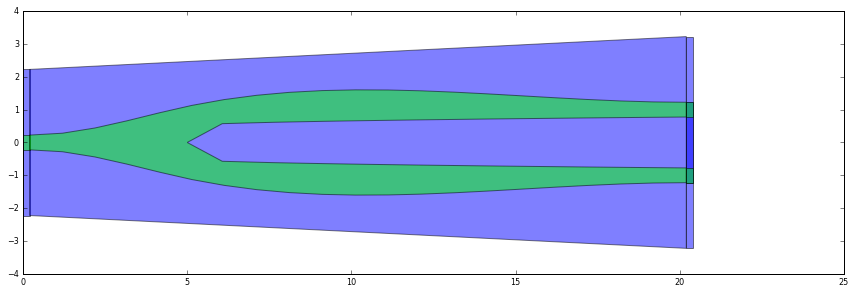

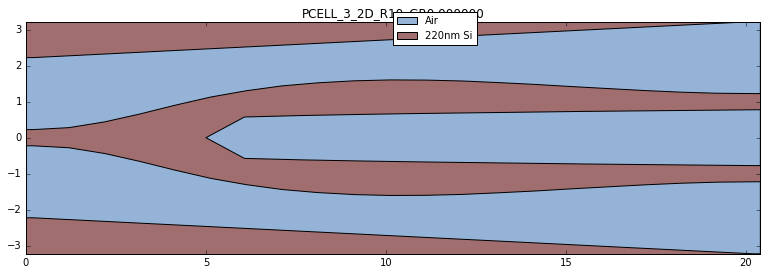

```python
from support_files.splitters import SplitterWaypoint


cell = SplitterWaypoint()
layout = cell.Layout(waypoint=i3.Coord2(5,1.1),
                     split_base_pos=5.0,
                     split_base_width=1.0,
                     length_splitting_shape=20.0
                    )
layout.visualize()
layout.visualize_2d()
```

## Step 2: Manual optimization of the splitter using CAMFR.

We can use CAMFR, a 1D Eigenmode expansion and 2D mode propagation tool, to simulate the this splitter. CAMFR is part of the Ipkiss distribution. Naturally this simulation will be approximate but it will be fast and is therefore an excellent tool for optimization.

The function simulate_splitter in simulate_splitter.py takes a layoutview as a parameter and returns the transmission and reflection.

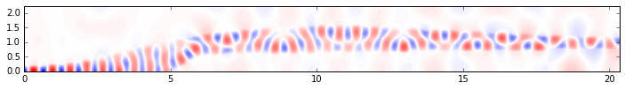

```
Transmission is -12.306445973 dB
Reflection is -46.2166015772 dB
```

```python
from support_files.simulate_splitter import simulate_splitter
(t,r) = simulate_splitter(layout=layout,plot=True, north=2.3)
print "Transmission is {} dB".format(10*log(t))
print "Reflection is {} dB".format(10*log(r))
```

In the interact below, I invite you to experiment with the dimensions of the splitter in order to try to obtain a decent transmission. Try to develop intuition on how the component behaves as well. Some hints are included as a comment in the function but, you can do better for sure.

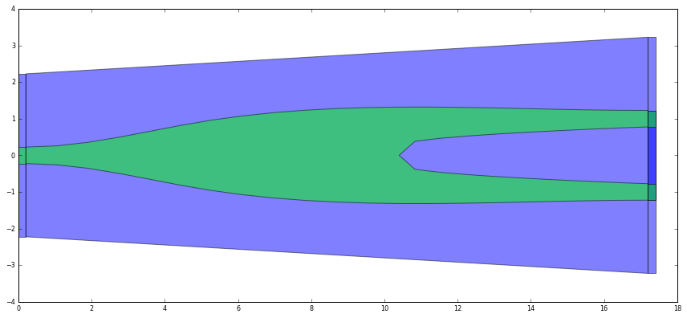

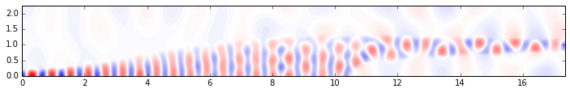

```
Transmission is -11.0026492873
Reflection is -48.4150523363
```

```
(0.33278290826560997, 0.007895161041067368)
```

```python
# from IPython.html.widgets import interact
def create_splitter(way_point_x,way_point_y,split_base_pos,split_base_width,length_splitting_shape,plot=True):
    cell = SplitterWaypoint()

    layout = cell.Layout(waypoint=i3.Coord2(way_point_x,way_point_y),
                        split_base_pos=split_base_pos,
                        split_base_width=split_base_width,
                        length_splitting_shape=length_splitting_shape
                        )
    if plot:
        layout.visualize()
    t,r= simulate_splitter(layout=layout, plot=plot,north=2.3)
    print "Transmission is {}".format(10*log(t))
    print "Reflection is {}".format(10*log(r))
    return t,r

from IPython.html.widgets import interact
interact(create_splitter,
         way_point_x = (0,10.0,0.1), #Hint 3.2
         way_point_y = (0,2.0,0.1), # Hint 1.1
         split_base_pos = (0.1,20.0,0.1), #Hint 11.7
         split_base_width= (0.01, 1.0,0.01), #Hint 0.35
         length_splitting_shape=(5,20,0.1), #Hint 17.2
        )
```

## Step 3: Automated opmization using python's optimization libraries.

We can now use the standard python optimization libraries to optimize the splitter. The function min_function(x) that is defined below takes in a vector x that is mapped onto the layout properties we want to optimize. It returns the minus of the transmission in dB which will be used as an objective function we want to minimize.

We use the manually obtained values as a starting point for our optimization (Hint values are used here by default)

```python
from scipy.optimize import minimize

def min_function(x):
    """
    x: np.array
    x[0] way_point_x
    x[1] way_point_y
    x[2] split_base_pos
    x[3] split_base_width
    x[4] length_splitting_shape
    """


    t,r = create_splitter(way_point_x=x[0],
                          way_point_y=x[1],
                          split_base_pos=x[2],
                          split_base_width=x[3],
                          length_splitting_shape=x[4],
                          plot=False)
    return -t

x0 = np.zeros([5])

x0[0] = 3.2
x0[1] = 1.1
x0[2] = 11.7
x0[3] = 0.35
x0[4] = 17.2

res = minimize(min_function,x0=x0,method='nelder-mead',options={'xtol': 1e-3, 'disp': True})
```

```
Transmission is -1.35957085423
Reflection is -86.6720239314
Transmission is -1.79630508188
Reflection is -87.2617094663
Transmission is -1.89648904438
Reflection is -85.0538318922
Transmission is -1.1557152129
Reflection is -74.0785541383
Transmission is -1.77968091521
Reflection is -94.3601600997
Transmission is -2.06687875867
Reflection is -76.344770414
Transmission is -0.849611583452
Reflection is -86.1611598087
Transmission is -2.32635174464
Reflection is -79.2235091862
Transmission is -1.77573698893
Reflection is -68.9340002939
Transmission is -0.95681489702
Reflection is -70.599881221
Transmission is -1.40954036683
Reflection is -85.1670772479
Transmission is -1.61020494607
Reflection is -76.0176852615
Transmission is -1.41881529327
Reflection is -89.6698331226
Transmission is -1.37699937687
Reflection is -71.0519157307
Transmission is -1.2079072908
Reflection is -83.1552457988
Transmission is -1.59024663618
Reflection is -71.6452825301
Transmission is -1.39168485047
Reflection is -68.1243275759
Transmission is -1.21004568012
Reflection is -115.527096693
Transmission is -1.09825128344
Reflection is -68.3033241542
Transmission is -1.90555399412
Reflection is -64.1624858412
```

[output cut: 165 more lines]

```
Reflection is -70.1355571847
Transmission is -0.793235766286
Reflection is -70.1355571847
Transmission is -0.793235766286
Reflection is -70.1355571847
Transmission is -0.793235766286
Reflection is -70.1355571847
Transmission is -0.793235766286
Reflection is -70.1355571847
Transmission is -0.793235766286
Reflection is -70.1355571847
Optimization terminated successfully.
         Current function value: -0.923741
         Iterations: 41
         Function evaluations: 108
```

```python
res
```

```
 final_simplex: (array([[  3.25522953,   1.10901057,  12.05368973,   0.35418294,
         16.49474912],
       [  3.25524982,   1.10901051,  12.05378526,   0.35416679,
         16.49556523],
       [  3.25527626,   1.10898352,  12.0535203 ,   0.35418061,
         16.49547623],
       [  3.25531317,   1.10905953,  12.05330904,   0.35418101,
         16.49466924],
       [  3.25536271,   1.10902225,  12.05318949,   0.35417506,
         16.49509201],
       [  3.25523598,   1.1090176 ,  12.05319564,   0.35418688,
         16.49510903]]), array([-0.92374098, -0.92374098, -0.92374098, -0.92374098, -0.92374098,
       -0.92374098]))
           fun: -0.92374097509072872
       message: 'Optimization terminated successfully.'
          nfev: 108
           nit: 41
        status: 0
       success: True
             x: array([  3.25522953,   1.10901057,  12.05368973,   0.35418294,  16.49474912])
```

This final optimization should have improved the insertion loss of your manual design a bit more. Naturally to reach the state-of-the-art a different parametrisation would be needed. A good start would be to use a second waypoint which once optimized might give better results still.

Lets have a look at the layout of our optimized coupler:

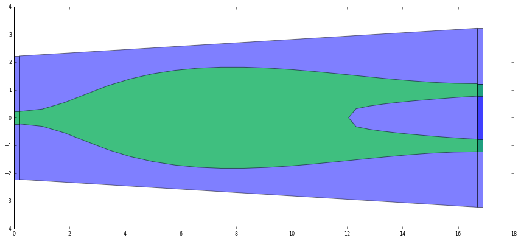

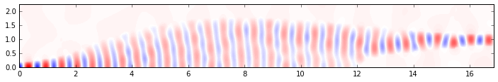

```
Transmission is -0.793235766286
Reflection is -70.1355571847
```

```python
#x_opt = np.array([  3.25522953,   1.10901057,  12.05368973,   0.35418294,  16.49474912])
x_opt = res.x
opt_coupler = SplitterWaypoint()
opt_coupler_layout = opt_coupler.Layout(waypoint=i3.Coord2(x_opt[0],x_opt[1]),
                    split_base_pos=x_opt[2],
                    split_base_width=x_opt[3],
                    length_splitting_shape=x_opt[4]
                    )
opt_coupler_layout.visualize()
t,r = simulate_splitter(layout=opt_coupler_layout, plot=True,north=2.3)
print "Transmission is {}".format(10*log(t))
print "Reflection is {}".format(10*log(r))
```

We will now use CST to simulate and create an accurate model for our splitter.

# Step 4: 3D-FIT simulation with CST and creation of an accurate S-matrix (beta)

It is possible to export any IPKISS virtually fabricated structure to CST Microwave studio and import the simulated S-Matrix back into IPKISS.

S-Matrices returned by CST are accurate on a broad spectrum as their FIT solvers take into account:

- Material dispersion.
- Modal shape dispersion.
- The roundness of boundaries.

<img src="_images/cst_flow.png" width=600>

#### Simulation flow step 1: Export your structure to CST.

The simulation flow allows for the export of a virtually fabricated structure to CST. To do this IPKISS creates a .mod file that can be read by CST.

The following information of your component is correctly transferred.

1. **Complete geometry**: The virtually fabricated layout as defined by the virtual fabrication rules in your TECHNOLOGY.
2. **Materials**: The optical properties of your materials as defined in your TECHNOLOGY.
3. **Ports**: The location and orientation of your ports.

A simulation with meaningful defaults is setup within CST. The following settings are set automatically but can of course be overruled manually.

1. **Grid**: The automatic meshing algorithms are used. You can set the bounding box of the mesh from IPKISS.
2. **Port excitation**: The ports are set to be used as sources with settings that are best suited for S-Parameters extraction.
3. **Field Monitors**: A field monitor is added for the entire structure but other field monitors can be added.

This is done in the code below:

First we delete the old project if it exists.

```python
# project name
projectname = "cst_coupler"

import os
# projectName and fullpath
directory = os.getcwd()
fullpath = os.path.join(directory, "simulation_files", projectname)
# delete old stuff
shutil.rmtree(fullpath, ignore_errors=True)
if os.path.isfile(fullpath + ".cst"):
    os.remove(fullpath + ".cst")
```

```python
si=opt_coupler_layout.size_info()
wavelength = 1.55e-6
freq0 = 1e-12 * 2.99792458e8 / wavelength
freq = [0.9*freq0, 1.1*freq0]

from luceda_cst.link.export import simulation_to_cst

simulation_to_cst(opt_coupler_layout,
                  frequency_range=freq,
                  port_height=0.75,
                  port_size= (1.2,1.2),
                  bounding_box = [[si.west,si.east], # [startx, stopx], propagation direction
                                  [-2, 2], # [starty,stopy]
                                  [0.15, 0.5 + 0.22 + 0.6]], # [startz, stopz], layer direction
                  cells_per_wav=6, #Use 10 for more accurate results (but slower simulations),
                  filename=r"simulation_files\{}".format(projectname))
```

```
A CST model simulation_files\cst_coupler.cst has been created, you can open this file with CST Studio
```

#### Simulation flow step 2: Adapt and run the simulation within CST.

Using the CST-GUI you can open the cst file and run the simulation as shown in the video below. You can also change the settings

<video controls src="_videos/cst_video_open_project.mp4" width=900>

Now: Open CST and open the cst_coupler.cst project.

This model is meant to be a **First start** with sensible defaults. You are free to use the CST-GUI to modify the properties of the simulation until you get what you want.

After the simulation is complete. Export the S-parameters to a Touchstone file format so that it can later be used by caphe. Do not forget to uncheck normalization of the impedance.

<video controls src="_videos/cst_simulation_results_and_touchstone_export.mp4" width=900>

This is flow is not fully automated - this is possible too but we will cover that later on.

#### Simulation flow step 3: Assign the simulated model to the splitter

We now use an model that imports the S-Parameters from a Touchstone file and pushes them into a model. Values are integrated between wavelengths that were not exactly simulated. This model will now be used when this splitter is used in a circuit.

**Note** A warning will be issued if the phase between the simulation frequency points varies more than pi/2 as the phase information might unreliable then.

[output not shown]

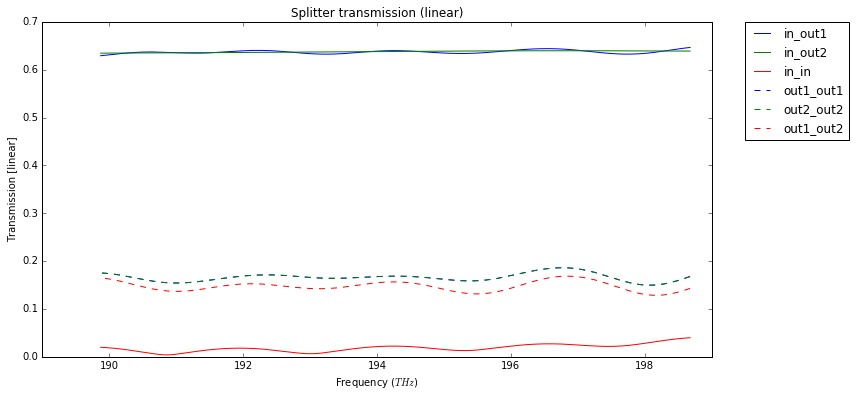

```python
cm_cst = opt_coupler.CapheModelCST(cst_touchstone_file="simulation_files/cst_coupler.s3p")
opt_coupler.set_default_view("CapheModelCST")
wavelengths =  np.linspace(1.51, 1.58, 501)
S = cm_cst.get_smatrix(wavelengths=wavelengths)


frequencies = 3e8/wavelengths * 1e-6
plt.plot(frequencies , np.abs(S['in', 'out1']), 'b', label='in_out1')
plt.plot(frequencies, np.abs(S['in', 'out2']), 'g', label='in_out2')
plt.plot(frequencies, np.abs(S['in', 'in']), 'r', label='in_in')
plt.plot(frequencies, np.abs(S['out1', 'out1']), 'b--', label='out1_out1')
plt.plot(frequencies, np.abs(S['out2', 'out2']), 'g--', label='out2_out2')
plt.plot(frequencies, np.abs(S['out1', 'out2']), 'r--', label='out1_out2')


plt.title("Splitter transmission (linear)")
plt.xlabel("Frequency ($THz$)")
plt.ylabel("Transmission [linear]")
plt.legend(bbox_to_anchor=(1.05, 1), loc=2, borderaxespad=0)
plt.show()
```

You might get about a phase difference of more than $\pi/2$ between 2 frequency bins. This is of importance when the phase pickup in your component needs to be accurate. Indeed if the phase varies more than $\pi/2$ between two frequency bins, you might take attribute a phase difference of $\pi/2$ to a phase difference of $3\pi/2$. If you are only interested in the absolute value of the transmission you can ignore this warning. If you are interested in the phase pickup you have to increase the sampling frequency of your simulation.

Or plotted in dB, and as a function of wavelength:

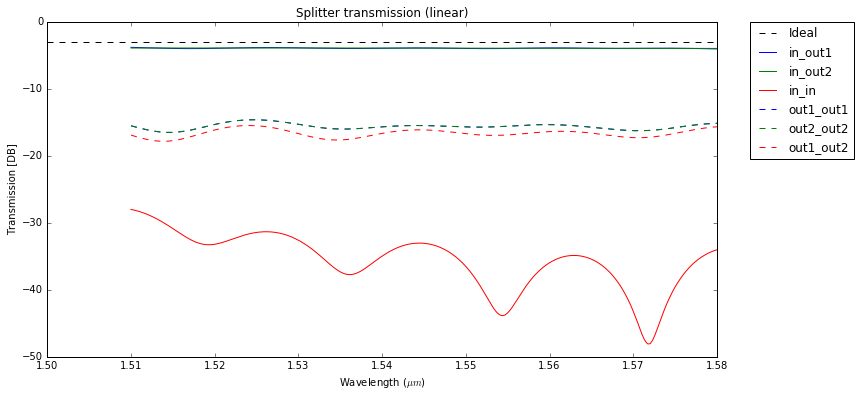

```python
plt.figure()
plt.axhline(y=-3.0,linewidth=1.0, label='Ideal', color='k', linestyle='--')
plt.plot(wavelengths , 20*log10(np.abs(S['in', 'out1'])), 'b', label='in_out1')
plt.plot(wavelengths, 20*log10(np.abs(S['in', 'out2'])), 'g', label='in_out2')
plt.plot(wavelengths, 20*log10(np.abs(S['in', 'in'])), 'r', label='in_in')
plt.plot(wavelengths, 20*log10(np.abs(S['out1', 'out1'])), 'b--', label='out1_out1')
plt.plot(wavelengths, 20*log10(np.abs(S['out2', 'out2'])), 'g--', label='out2_out2')
plt.plot(wavelengths, 20*log10(np.abs(S['out1', 'out2'])), 'r--', label='out1_out2')


plt.title("Splitter transmission (linear)")
plt.xlabel("Wavelength ($\mu m$)")
plt.ylabel("Transmission [DB]")
plt.legend(bbox_to_anchor=(1.05, 1), loc=2, borderaxespad=0)
plt.show()
```

**opt_coupler** can now be used as a cell in a circuit. It will have a layout and a circuit that match.

## Fully scripted simulations

What you have seen above is a one way-shot, meaning that you manually launch modify and lauch the simulation. For optimization purposes it may be best to do everything scripted. The good news is that this is possible too!

To achieve that goal one must do the following:

- Keep track of the modifications you made in the GUI.
- Start the simualtion and extract results from script from script.

We now will go over those steps.

### Keep track of the modifications made in the GUI.

As you interact with the GUI of CST, CST will add VBA commands to the history list. To avoid having to do these manipulations each time you can fetch those commands from your CST project as shown in the video below.

<video controls src="_videos/cst_save_additional_commmands.mp4" width=900>

The file (additional_commands.mod) was obtained in the GUI by adding port symmetries, changing mesh_settings and reduce the solver accuracy.

### Start the simulation and extract results from script from script.

In order to run a CST simulation in batch mode, we will first create a model including the additional commands saved in the file additional_commands.mod as well as the postprocessing steps which we want to be performed after each simulation run. The postprocessing steps are defined via VBA code in the file postprocessing_commands.mod. Here we just save the S-Parameter in a touchstone file. However using this approach you have access to all results and postprocessing functionalities provided by CST.

```python
projectname = 'scripted_coupler'
directory = os.getcwd()
fullpath = os.path.join(directory, "simulation_files", projectname)
# delete old stuff
shutil.rmtree(fullpath, ignore_errors=True)
if os.path.isfile(fullpath + ".cst"):
    os.remove(fullpath + ".cst")
```

```python
simulation_to_cst(opt_coupler_layout,
                  frequency_range=freq,
                  port_height=0.75,
                  port_size= (1.2,1.2),
                  bounding_box = [[si.west,si.east], # [startx, stopx], propagation direction
                                  [-2, 2], # [starty,stopy]
                                  [0.15, 0.5 + 0.22 + 0.6]], # [startz, stopz], layer direction
                  cells_per_wav=7,
                  filename=r"simulation_files\{}".format(projectname),
                  additional_commands_path = r"simulation_files\additional_commands.mod"
                  )
```

```
A CST model simulation_files\scripted_coupler.cst has been created, you can open this file with CST Studio
```

Now we can perform the simulation using the command line interface. Here the simulation runs locally but using this approach it is although possible to perform the Simulation on another more powerfull machine by adding additional flags to the command line invocation.

We now start the solver ...

```python
import subprocess as sub
# This is the default location - change if installed in a different location.
command = '"C:\Program Files (x86)\CST STUDIO SUITE 2017\CST DESIGN ENVIRONMENT.exe" -m -rebuild'

# run time domain simulation
p = sub.Popen(command + " -r " + r"simulation_files\{}.cst".format(projectname), stdout=sub.PIPE, stderr=sub.PIPE)
output, errors = p.communicate()
```

```python
# print the command line output
print output
```

```python
cm_cst = opt_coupler.CapheModelCST(cst_touchstone_file=r"simulation_files\{}.s3p".format(projectname))
opt_coupler.set_default_view("CapheModelCST")
wavelengths =  np.linspace(1.51, 1.58, 501)
S = cm_cst.get_smatrix(wavelengths=wavelengths)

frequencies = 3e8/wavelengths * 1e-6
plt.plot(frequencies , np.abs(S['in', 'out1']), 'b', label='in_out1')
plt.plot(frequencies, np.abs(S['in', 'out2']), 'g', label='in_out2')
plt.plot(frequencies, np.abs(S['in', 'in']), 'r', label='in_in')
plt.plot(frequencies, np.abs(S['out1', 'out1']), 'b--', label='out1_out1')
plt.plot(frequencies, np.abs(S['out2', 'out2']), 'g--', label='out2_out2')
plt.plot(frequencies, np.abs(S['out1', 'out2']), 'r--', label='out1_out2')

plt.title("Splitter transmission (linear)")
plt.xlabel("Frequency ($THz$)")
plt.ylabel("Transmission [linear]")
plt.legend(bbox_to_anchor=(1.05, 1), loc=2, borderaxespad=0)
plt.show()
```

## Use the component iself to generate and simulate the models

Once you have consolidated the simulation setting you want to use you can use CapheModelCST to wrap all the properties of simulation_to_cst. You can therefore specify all the properties of the simulation and the additional commands as properties of the model itself.

```python
x_opt = res.x
opt_coupler_new = SplitterWaypoint(name="optimized_splitter")
opt_coupler_layout = opt_coupler_new.Layout(waypoint=i3.Coord2(x_opt[0],x_opt[1]),
                    split_base_pos=x_opt[2],
                    split_base_width=x_opt[3],
                    length_splitting_shape=x_opt[4]
                    )
```

You can then use the command `generate_first_cst_project` to initialize and initial project in which you can set the addional commands

```python
cst_model = opt_coupler_new.CapheModelCST()
cst_model.generate_first_cst_project()
```

The additional_commands is included as a property of the model along with other properties of the simulation

```python
print cst_model.additional_commands_path
print cst_model.cells_per_wave
```

You can then use the command `simulate_cst_project` to simulate the whole project includeing the addional commands and postprocesisng commands.

```python
cst_model.simulate_cst_project()
```

After the project has been simulated the smatrix can be plotted.

```python
wavelengths =  np.linspace(1.51, 1.58, 501)
S = cst_model.get_smatrix(wavelengths=wavelengths)

frequencies = 3e8/wavelengths * 1e-6
plt.plot(frequencies , np.abs(S['in', 'out1']), 'b', label='in_out1')
plt.plot(frequencies, np.abs(S['in', 'out2']), 'g', label='in_out2')
plt.plot(frequencies, np.abs(S['in', 'in']), 'r', label='in_in')
plt.plot(frequencies, np.abs(S['out1', 'out1']), 'b--', label='out1_out1')
plt.plot(frequencies, np.abs(S['out2', 'out2']), 'g--', label='out2_out2')
plt.plot(frequencies, np.abs(S['out1', 'out2']), 'r--', label='out1_out2')

plt.title("Splitter transmission (linear)")
plt.xlabel("Frequency ($THz$)")
plt.ylabel("Transmission [linear]")
plt.legend(bbox_to_anchor=(1.05, 1), loc=2, borderaxespad=0)
plt.show()
```